# Combined report on missings patterns.

Piotr Fic

11 08 2020

### Data used.

- The report was created on the basis of information on 132 datasets, both from the regression and classification tasks.

## Key information about distribution of missings.

### *Figure 1*

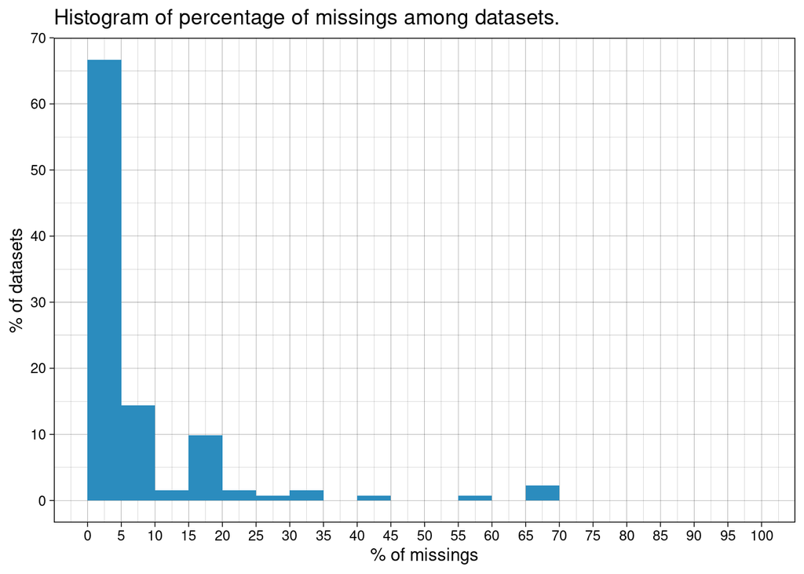

- Most of the datasets have missings percentage lower than 5%.
- About 25% of datasets have a fraction of missings between 5% to 20%.
- Higher percentages of missings occur in a small number of datasets.

### *Figure 2*

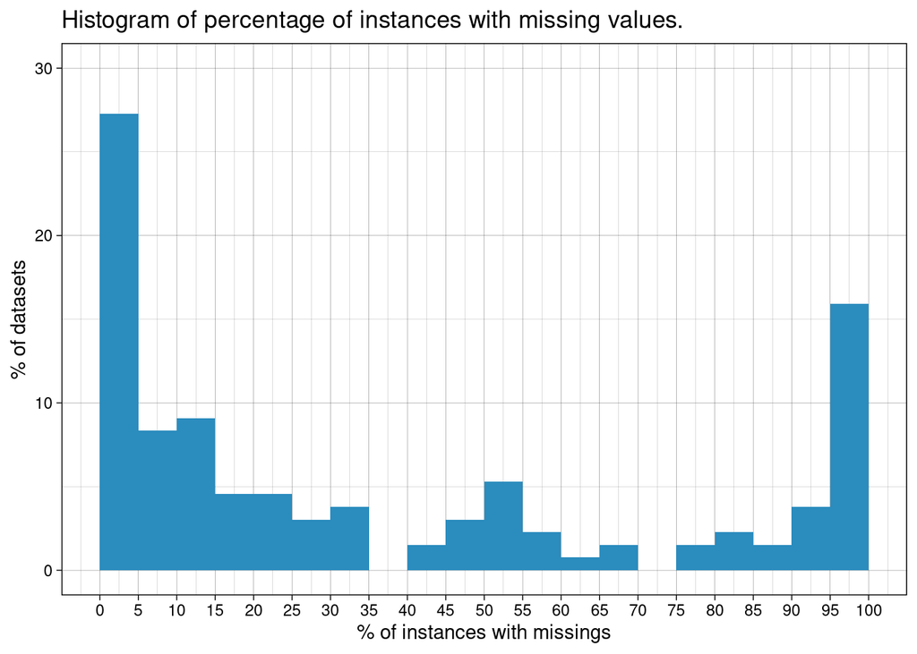

- There are two dominant groups of occurrence of missings among instances.
- The first group contains datasets where the percentage of instances with missings is lower than 15%.
- The second group is formed by datasets with a very high percentage of instances with missings (above 90%).

### *Figure 3*

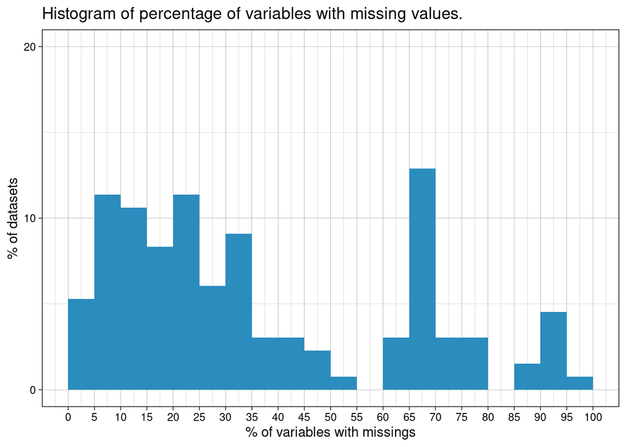

## Key information about distribution of missings patterns.

### *Figure 4*

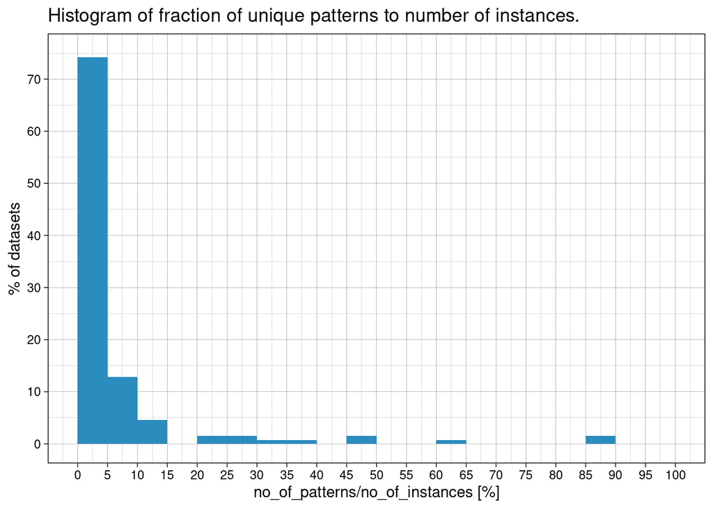

- The figure above presents a dispersion of missings’ pattern among datasets.
- Most of the datasets have patterns which have less than 10% of unique combinations compared to  
  the number of instances in datasets.
- There are very few datasets which have diverse patterns with a unique combination for most rows of the dataset.

### *Figure 5*

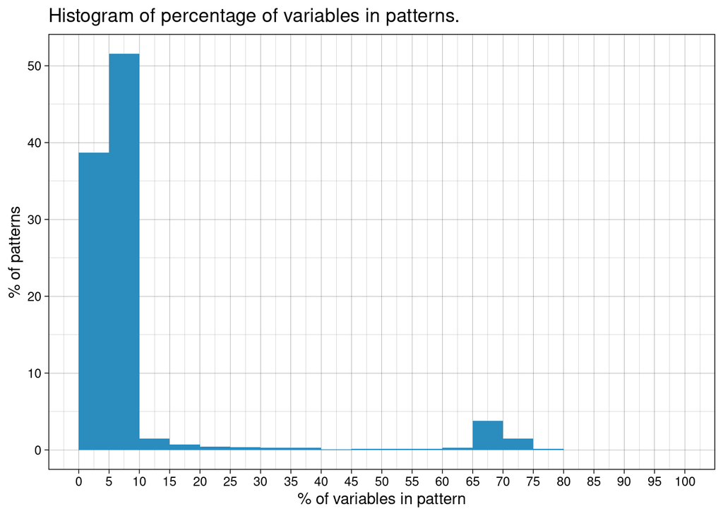

- Percentage of variables in the pattern means a fraction of variables in dataset’s row which have missing values.  
  Different combinations of variables with missings create missings patterns.
- Most of the missings patterns contain less than 10% of variables.
- The second noticeable, but small group create patterns with the percentage of variables between 65% to 75%.

### *Figure 6*

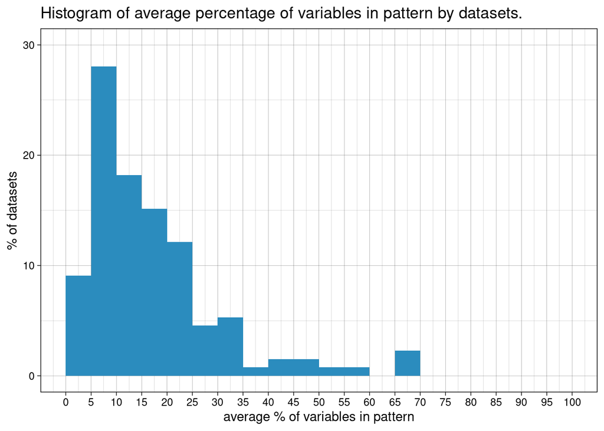

- On the figure above the percentage of variables in patterns is averaged for every dataset.
- Averaging by datasets introduce more diversity in distribution.
- Conclusions remain similar, most of the datasets have patterns which on average contain less than 25% of variables.

### *Figure 7*

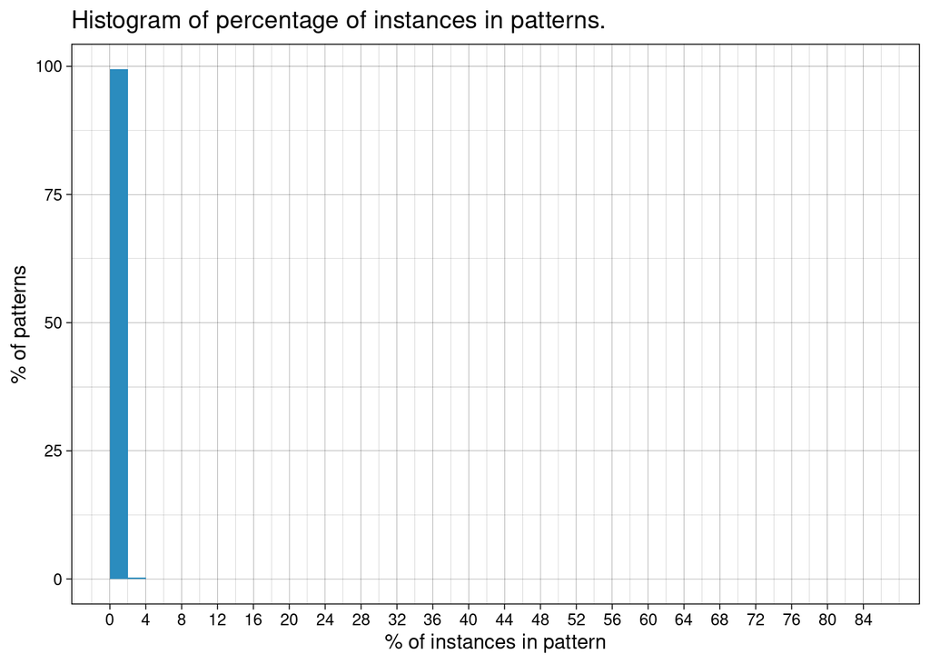

- Almost all patterns seem to cover an only very small fraction of dataset’s instances.

### *Figure 8*

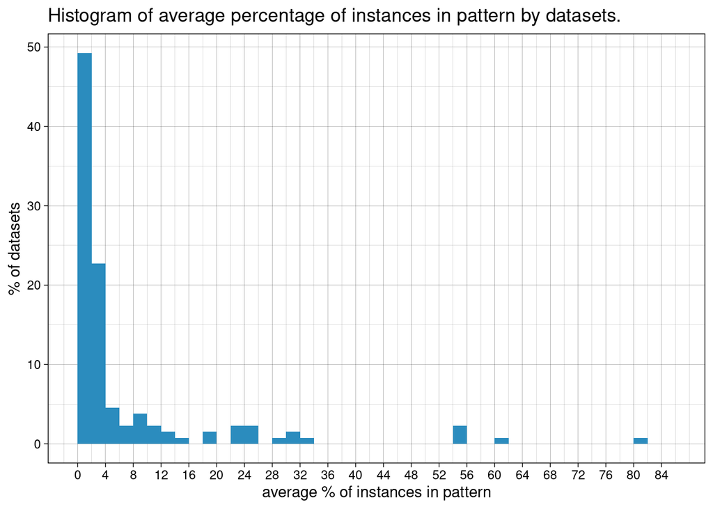

- Calculating the average of a number of instances in patterns for each dataset help to see more diversity.
- Still for most datasets a single pattern on average covers below 4% of instances.
- However, some datasets have missings patters which on the average cover more than half of the instances in the dataset.

## Decision tree

Based on the above analysis, we can try to group data sets against key statistics.

### *Tree 1*

Splitting variables:

- percentage of missings [10]
- percentage of instances with missings [15, 90]
- fraction of patterns in instances [10]

[interactive chart not shown]

### *Tree 2*

Splitting variables:

- percentage of missings [5]
- percentage of instances with missings [35]
- fraction of patterns in instances [10]

[interactive chart not shown]

### *Tree 3*

Splitting variables:

- percentage of missings [5]
- percentage of instances with missings [35]
- fraction of patterns in instances [10]

[interactive chart not shown]

### *Tree 4*

Splitting variables:

- percentage of missings [5]
- percentage of instances with missings [15]
- average percentage of variables in dataset’s patterns [10, 25]

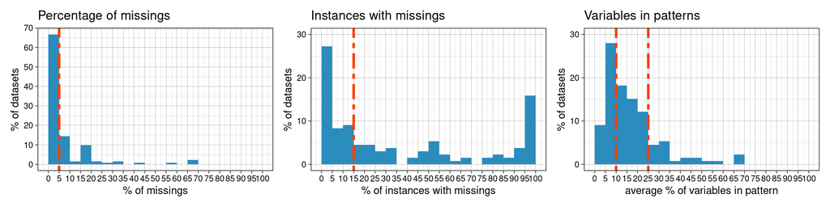

[interactive chart not shown]

|  | 1_avg | 1_sd |
| --- | --- | --- |
| per_missings | 0.2 | 0.2 |
| per_variables_missings | 13.9 | 12.8 |
| per_instances_missings | 3.4 | 3.3 |
| patterns_fraction | 1.4 | 1.6 |
| avg_per_var_pattern | 7.4 | 2.4 |
| avg_per_inst_pattern | 2.0 | 1.8 |

| 2_avg | 2_sd |
| --- | --- |
| 1.1 | 0.7 |
| 37.8 | 20.8 |
| 7.0 | 3.9 |
| 2.0 | 2.0 |
| 17.7 | 4.3 |
| 2.2 | 1.9 |

| 3_avg | 3_sd |
| --- | --- |
| 0.2 | 0.4 |
| 34.4 | 5.7 |
| 0.5 | 1.0 |
| 0.2 | 0.4 |
| 34.4 | 5.7 |
| 0.5 | 1.0 |

| 4_avg | 4_sd |
| --- | --- |
| 2.1 | 1.3 |
| 21.0 | 19.5 |
| 52.6 | 28.3 |
| 8.3 | 20.4 |
| 5.5 | 2.4 |
| 14.0 | 10.7 |

| 5_avg | 5_sd |
| --- | --- |
| 2.8 | 0.7 |
| 35.4 | 16.6 |
| 30.9 | 13.1 |
| 4.1 | 4.3 |
| 12.2 | 1.9 |
| 3.9 | 2.9 |

| 6_avg | 6_sd |
| --- | --- |
| 4.6 | 0.2 |
| 66.7 | 0.0 |
| 18.1 | 0.6 |
| 7.7 | 0.1 |
| 25.0 | 0.0 |
| 3.0 | 0.1 |

| 7_avg | 7_sd |
| --- | --- |
| 6.4 | 0.9 |
| 18.6 | 7.7 |
| 93.2 | 15.8 |
| 6.5 | 11.2 |
| 7.7 | 1.0 |
| 11.6 | 24.3 |

| 8_avg | 8_sd |
| --- | --- |
| 12.4 | 5.9 |
| 50.3 | 25.4 |
| 77.8 | 22.8 |
| 9.9 | 14.9 |
| 17.8 | 4.3 |
| 13.2 | 16.6 |

| 9_avg | 9_sd |
| --- | --- |
| 31.6 | 22.0 |
| 76.3 | 19.0 |
| 72.2 | 30.5 |
| 17.3 | 24.9 |
| 43.5 | 16.2 |
| 10.4 | 23.1 |

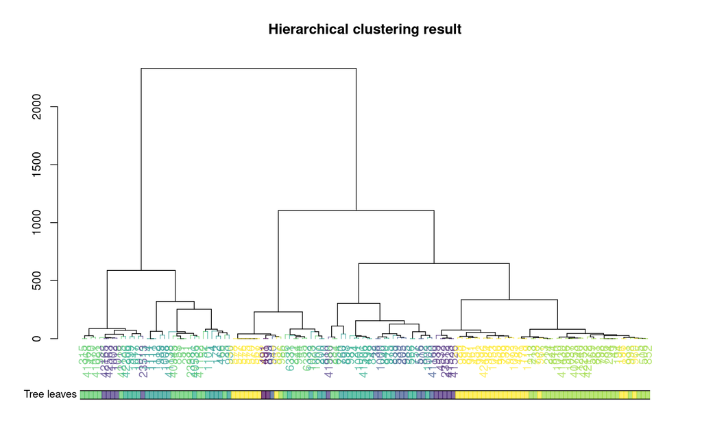

### *Tree 5*

Splitting variables:

- percentage of missings [5]
- percentage of instances with missings [15]
- percentage of variables with missings [15, 60]

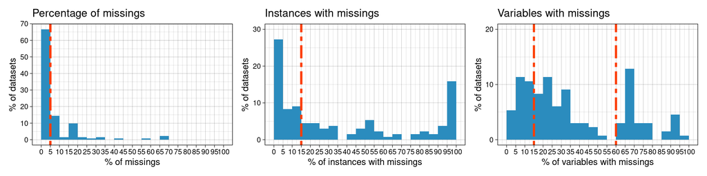

[interactive chart not shown]

|  | 1_avg | 1_sd |
| --- | --- | --- |
| per_missings | 0.2 | 0.2 |
| per_variables_missings | 9.9 | 4.0 |
| per_instances_missings | 3.2 | 3.3 |
| patterns_fraction | 1.2 | 1.3 |
| avg_per_var_pattern | 7.6 | 2.9 |
| avg_per_inst_pattern | 2.2 | 1.9 |

| 2_avg | 2_sd |
| --- | --- |
| 0.8 | 0.8 |
| 27.9 | 8.2 |
| 4.4 | 3.6 |
| 1.5 | 2.1 |
| 19.3 | 8.9 |
| 1.9 | 2.1 |

| 3_avg | 3_sd |
| --- | --- |
| 1.5 | 0.5 |
| 68.3 | 3.7 |
| 10.8 | 0.5 |
| 3.2 | 1.3 |
| 18.2 | 4.1 |
| 1.3 | 0.3 |

| 4_avg | 4_sd |
| --- | --- |
| 1.9 | 1.4 |
| 7.2 | 4.5 |
| 44.7 | 26.9 |
| 1.6 | 1.7 |
| 5.1 | 2.9 |
| 21.8 | 6.9 |

| 5_avg | 5_sd |
| --- | --- |
| 2.7 | 1.0 |
| 31.8 | 8.9 |
| 46.8 | 27.8 |
| 10.4 | 22.1 |
| 9.3 | 3.5 |
| 4.6 | 3.8 |

| 6_avg | 6_sd |
| --- | --- |
| 3.2 | 1.7 |
| 70.2 | 5.6 |
| 27.9 | 15.6 |
| 7.6 | 0.9 |
| 17.0 | 9.8 |
| 1.6 | 1.6 |

| 7_avg | 7_sd |
| --- | --- |
| 6.3 | 0.8 |
| 10.6 | 2.2 |
| 67.8 | 21.6 |
| 7.9 | 14.1 |
| 9.9 | 3.2 |
| 42.8 | 28.7 |

| 8_avg | 8_sd |
| --- | --- |
| 14.5 | 7.8 |
| 30.3 | 10.6 |
| 86.7 | 20.9 |
| 4.4 | 10.0 |
| 17.9 | 12.2 |
| 19.2 | 23.1 |

| 9_avg | 9_sd |
| --- | --- |
| 22.9 | 20.6 |
| 77.7 | 11.9 |
| 74.3 | 27.9 |
| 17.5 | 22.0 |
| 33.1 | 17.5 |
| 2.7 | 2.7 |

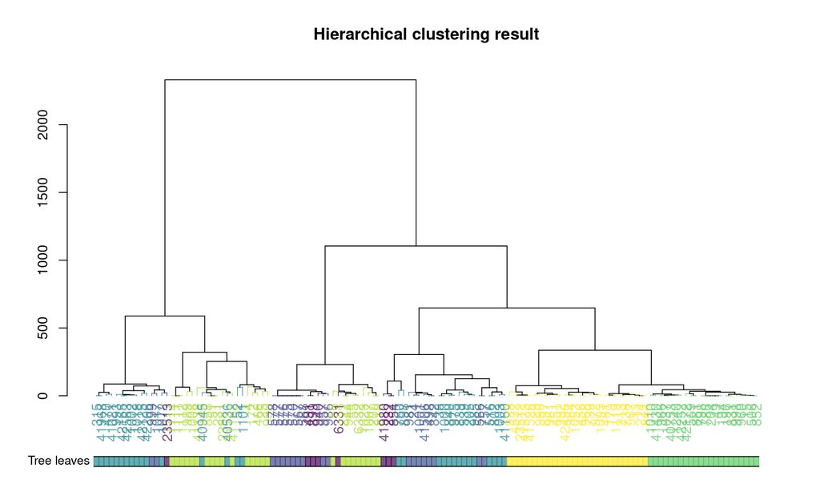

## Conclusions from decisions trees and clustering

- there are two significant groups of datasets: the first with a low average percentage of missings and instances with missings, the second opposite with a high average of missings and instances with missings
- the third noticeable group are datasets with a low percentage of missings but scattered to a larger number of observations (middle subtree)
- statistics describing the distribution of deficiencies into variables introduce differentiation in each of the previously obtained sub-trees
- there is a tendency that datasets with a low number of missings have a low number of columns with missings and the opposite for datasets with a large number of missings
- hierarchical clustering results partially support grouping by decision trees, the extreme left and right branches of the tree form their own clusters
- it is difficult to analyze the middle subtrees, where the relationships are not easily interpreted, leaves are mixed among clusters